# Reproducing the 100 × 100 emulation experiment with spDBL

This is a package-based rerun of `vignettes/reproduce/emulate_EP_MNIW.R`. It uses **all 50 original saved simulator runs**, the original 100 × 100 grid, and all 51 time points. The first 40 inputs train the model; inputs 41–50 are held out. No spatial or temporal subsampling is used. The saved values are already on the $\log(I+1)$ scale.

The first experiment reconstructs the inverse-Wishart emulator’s heat maps and prediction comparisons. The second compares the **MNIW, MNIG, and identity** right-covariance models using episode-level log predictive density, WAIC, and the development script’s G/P/D calculation.

These research reports use the repository’s `data/` directory. They live outside the spDBL package source; ordinary package builds do not include them or the large original CSV datasets.

## Match the original setup

| Setting | Original script and this run |
| --- | --- |
| Simulator inputs | Original `data/emulation/pde_para.csv`, rows 1–50 |
| Training / validation | Rows 1–40 / 41–50 |
| Grid and time | 100 × 100; times 0–50 |
| AR design | AR2; the original special initialization at the first two times |
| Block size | One 100-cell strip; 100 blocks per time |
| Episode count | 5,100 |
| Coefficient matrix | 200 × 100 |
| Kernel | Exponential, tuning 0.5, amplitude 1.1, nugget 0.0001 |
| State prior | All-one mean, identity left covariance, $G=W=I$ |
| Covariance priors | MNIW: $n_0=203,D_0=I_{100}$; MNIG: $n_0=203,D_0=300$ |
| Sampling | Ten smoothed-marginal coefficient sets; seed 1234 |

The large-grid experiment calls exported `spDBL::FFBS()`, `FFBS_sampling()`, and `FFBS_predict_exact()` directly. This retains the original episode calculations without allocating an unused full-grid 10,000 × 10,000 covariance matrix. The scalar and identity comparisons use `FFBS_sigma2R()` and `FFBS_I()` respectively. The shared helper reads the CSVs without modifying them and records their MD5 checksums.

```r
# d contains the original CSV responses, rearranged to time-indexed matrices.
# s contains their original block indices, AR2 rows, and kernels.
fit <- spDBL::FFBS(
  Y = s$Y, F_ls = s$F, G_ls = diag(s$P), W_ls = diag(s$P),
  V_ls = s$V, m0 = matrix(1, s$P, s$C), M0 = diag(s$P),
  n0 = s$P + 3, D0 = diag(s$C), nT = s$E, delta = 1
)
draws <- spDBL::FFBS_sampling(
  10, fit, s$F, diag(s$P), s$E, sampling = "marginal"
)
prediction_EP <- spDBL::FFBS_predict_exact(
  s$Y, fit, s$F, s$F_test, d$input[1:40, ], d$input[41:50, ],
  s$E, s$phi
)
prediction <- spDBL::recover_from_EP_exact(
  prediction_EP, d$T, s$E, s$block_cols
)
```

## Run or reuse verified experiment results

The following call runs the full experiment on first execution. Each completed model is saved independently, so an interrupted model-comparison run can resume without refitting completed models. A changed input checksum, numerical helper implementation, configuration, or package version invalidates the cache and produces an error instead of silently showing stale results.

```r
r <- if (isTRUE(params$render_only)) reproduction_cached_results(root, "emulation") else
  run_emulation_reproduction(root)
r$manifest$settings
```

```
## $Nx
## [1] 100
##
## $Ny
## [1] 100
##
## $times
##  [1]  0  1  2  3  4  5  6  7  8  9 10 11 12 13 14 15 16 17 18 19 20 21 22 23 24
## [26] 25 26 27 28 29 30 31 32 33 34 35 36 37 38 39 40 41 42 43 44 45 46 47 48 49
## [51] 50
##
## $train
##  [1]  1  2  3  4  5  6  7  8  9 10 11 12 13 14 15 16 17 18 19 20 21 22 23 24 25
## [26] 26 27 28 29 30 31 32 33 34 35 36 37 38 39 40
##
## $validation
##  [1] 41 42 43 44 45 46 47 48 49 50
##
## $window
## [1] 1
##
## $nsam
## [1] 10
##
## $AR
## [1] 2
##
## $seed
## [1] 1234
##
## $gp_tune
## [1] 0.5
##
## $gp_sigma2
## [1] 1.1
##
## $gp_tau2
## [1] 1e-04
##
## $sampling
## [1] "marginal"
```

## Held-out prediction

```r
knitr::kable(r$models$MNIW$validation, digits = 6,
  caption = "Errors on the saved log(I + 1) scale; all sites and times.")
```

Errors on the saved log(I + 1) scale; all sites and times.

| method | input_id | RMSE | MAE | max_abs_error |
| --- | --- | --- | --- | --- |
| AR2 with saved held-out lags | 41 | 0.080554 | 0.024457 | 5.548881 |
| AR2 with saved held-out lags | 42 | 0.079734 | 0.016587 | 3.014811 |
| AR2 with saved held-out lags | 43 | 0.033429 | 0.006812 | 1.063035 |
| AR2 with saved held-out lags | 44 | 0.063355 | 0.012177 | 2.635549 |
| AR2 with saved held-out lags | 45 | 0.121630 | 0.021972 | 5.115597 |
| AR2 with saved held-out lags | 46 | 0.117662 | 0.037442 | 7.114846 |
| AR2 with saved held-out lags | 47 | 0.093928 | 0.018486 | 3.395642 |
| AR2 with saved held-out lags | 48 | 0.106916 | 0.032358 | 5.200317 |
| AR2 with saved held-out lags | 49 | 0.163060 | 0.045705 | 13.526050 |
| AR2 with saved held-out lags | 50 | 0.036314 | 0.007208 | 1.096813 |

Pooling all held-out cells gives RMSE **0.097353**.

These figures use the original blue–green–red palette from `R/func_plot.R`, colour limits from zero to the maximum across all ten held-out trajectories, the original panel arrangements and labels, and legends on the right. The error panels use black points and error bars with alpha `0.1 / 3`, a red identity line, and the original division by population 10,000. The minimal theme, font sizes, figure dimensions, and export resolutions match the source script. Numerical emulation results are reused without refitting.

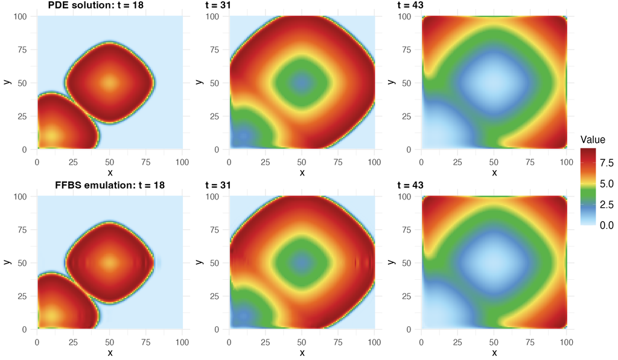

The original comparison: held-out input 42, at times 18, 31, and 43.

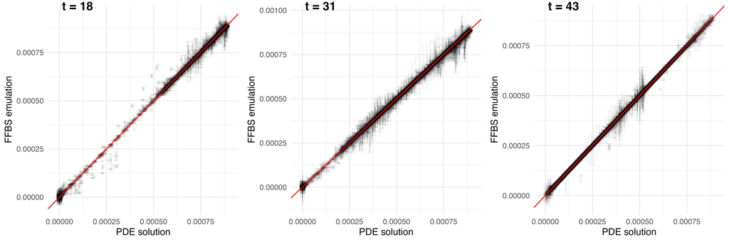

Original plotting scale: saved log(I + 1) responses divided by population 10,000. Intervals summarize coefficient-conditioned means.

As in the original script, these AR2 prediction rows are constructed using the **held-out simulator trajectories themselves**. This evaluates emulation conditional on saved lag features; it is not a PDE-free forecast at an input with no trajectory available. The calibration vignette separately evaluates the offline GP that supplies these rows without a PDE solution.

The ten-draw intervals above summarize variation of conditional means. They omit new-input GP residual variation and are not full predictive intervals. The package’s current marginal sampler has the same marginal target as the original sampler, but its random-number implementation can give different individual draws.

## Three covariance models

For each episode $e$, retain the original matrix-valued likelihood unit:

$$\ell_e=\log\left\{\frac1M\sum_{m=1}^M
p(Y_e\mid\Theta_e^{(m)},\Sigma^{(m)})\right\},
\qquad p_e=\operatorname{Var}_{m=1,\ldots,M}\left[\log
p(Y_e\mid\Theta_e^{(m)},\Sigma^{(m)})\right],$$

$$\operatorname{WAIC}=-2\sum_e(\ell_e-p_e).$$

The likelihood is matrix normal with row covariance $V$ and right covariance $\Sigma^{(m)}$, $\sigma_m^2 R$, or $I$. The helper caches Cholesky factors and checks its optimized density against `mniw::dMNorm()` before computing scores. Analytic densities use the package’s exported `lppd_*_1t()` functions and the terminal covariance posterior, as in the original script.

```r
knitr::kable(r$comparison[, c("model", "lppd", "lppd_analytic", "p_waic", "WAIC")],
  digits = 3, caption = "Full-data covariance comparison.")
```

Full-data covariance comparison.

|  | model | lppd | lppd_analytic | p_waic | WAIC |
| --- | --- | --- | --- | --- | --- |
| MNIW | MNIW | 77840201 | 79347612 | 5157057 | -145366288 |
| MNIG | MNIG | 55690351 | 57050485 | 4742574 | -101895552 |
| I | I | -17061335 | -16211316 | 3220959 | 40564587 |

```r
knitr::kable(r$comparison[, c("model", "G", "P", "D")], digits = 3,
  caption = "G/P/D formulas preserved from the development script.")
```

G/P/D formulas preserved from the development script.

|  | model | G | P | D |
| --- | --- | --- | --- | --- |
| MNIW | MNIW | 30391.05 | 19066481 | 19096872 |
| MNIG | MNIG | 30391.05 | 29829018 | 29859409 |
| I | I | 30391.05 | 9350207723 | 9350238114 |

```r
knitr::kable(r$comparison[, c("model", "FFBS_seconds", "sampling_seconds", "scoring_seconds")],
  digits = 1, caption = "Elapsed time by stage, in seconds.")
```

Elapsed time by stage, in seconds.

|  | model | FFBS_seconds | sampling_seconds | scoring_seconds |
| --- | --- | --- | --- | --- |
| MNIW | MNIW | 24.3 | 135.4 | 38.7 |
| MNIG | MNIG | 63.3 | 133.7 | 41.4 |
| I | I | 60.6 | 59.4 | 37.9 |

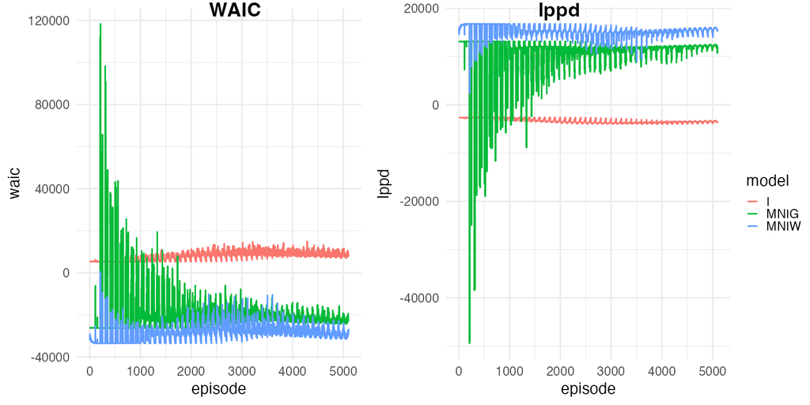

`G`, `P`, and `D=G+P` intentionally reproduce the development script’s formulas, including its `trace(St)` penalty and MNIW divisor `nt - 2`. They should be read as a reproduction of that implementation, rather than a new derivation of posterior predictive loss. WAIC uses sample variance across ten draws; such a small Monte Carlo sample can be unstable. Analytic lppd and Monte Carlo lppd are shown separately rather than assumed numerically equal.

## Re-run

From the repository root:

```bash
R CMD INSTALL --library=spDBL/.r-library spDBL
Rscript vignettes/reproduce_spDBL/run_reproduction.R emulation
```

The HTML is self-contained. Numerical summaries, full held-out means, selected MC arrays, CSV tables, input checksums, and session information are saved under `vignettes/reproduce_spDBL/_results/emulation/`. To intentionally change the setup or implementation, move this result directory aside first and run again.

[session information not shown]